# Premier League study

#### Loading data

```r
glimpse(df)
```

```
## Observations: 6,926
## Variables: 14
## $ X                 <int> 0, 1, 2, 3, 4, 5, 6, 7, 8, 9, 10, 12, 13, 11...
## $ home_team         <fct> Charlton, Chelsea, Coventry, Derby, Leeds, L...
## $ away_team         <fct> Man City, West Ham, Middlesbrough, Southampt...
## $ date              <fct> 2000-08-19, 2000-08-19, 2000-08-19, 2000-08-...
## $ home_goals        <int> 4, 4, 1, 2, 2, 0, 1, 1, 3, 2, 2, 1, 1, 2, 3,...
## $ away_goals        <int> 0, 2, 3, 2, 0, 0, 0, 0, 1, 0, 0, 1, 1, 0, 0,...
## $ referee           <fct> Rob Harris, Graham Barber, Barry Knight, And...
## $ home_fouls        <int> 13, 19, 15, 11, 21, 12, 8, 10, 14, 7, 25, 10...
## $ away_fouls        <int> 12, 14, 21, 13, 20, 12, 8, 21, 13, 13, 20, 7...
## $ home_yellow_cards <int> 1, 1, 5, 1, 1, 2, 1, 3, 0, 0, 2, 1, 2, 0, 2,...
## $ away_yellow_cards <int> 2, 2, 3, 1, 3, 3, 1, 1, 0, 1, 4, 4, 1, 1, 1,...
## $ home_red_cards    <int> 0, 0, 1, 0, 0, 0, 0, 0, 0, 0, 1, 0, 0, 0, 0,...
## $ away_red_cards    <int> 0, 0, 0, 0, 0, 0, 0, 1, 0, 0, 2, 0, 0, 0, 1,...
## $ season            <int> 1, 1, 1, 1, 1, 1, 1, 1, 1, 1, 1, 1, 1, 1, 1,...
```

### **First “To do” list of things**:

- Delete ‘**x**’ attribute. Not needed.
- Format data attributes porperly.
  - **date:** As date, not factor.
  - **season:** As factor, not integer.

#### Selecting all attributes but ‘x’

```r
df = df[,2:ncol(df)]
names(df)
```

```
##  [1] "home_team"         "away_team"         "date"
##  [4] "home_goals"        "away_goals"        "referee"
##  [7] "home_fouls"        "away_fouls"        "home_yellow_cards"
## [10] "away_yellow_cards" "home_red_cards"    "away_red_cards"
## [13] "season"
```

#### Formatting data

```r
df$date = as_date(df$date)
df$season = factor(df$season)

glimpse(df[c("date", "season")])
```

```
## Observations: 6,926
## Variables: 2
## $ date   <date> 2000-08-19, 2000-08-19, 2000-08-19, 2000-08-19, 2000-0...
## $ season <fct> 1, 1, 1, 1, 1, 1, 1, 1, 1, 1, 1, 1, 1, 1, 1, 1, 1, 1, 1...
```

## **1. For each season, which team(s) committed the most fouls?**

*Let’s take a look at the Top 3 teams that commited the most fouls for each season.*

```r
home = df %>%
  select(home_team, home_fouls, season) %>%
  group_by(season, home_team) %>%
  summarise(home_fouls = sum(home_fouls))

away = df %>%
  select(away_team, away_fouls, season) %>%
  group_by(season, away_team) %>%
  summarise(away_fouls = sum(away_fouls))

most_fouls = data.frame(season = home$season,
                        team = home$home_team,
                        total_fouls = home$home_fouls + away$away_fouls,
                        home_fouls = home$home_fouls,
                        away_fouls = away$away_fouls) %>%
  arrange(season, desc(total_fouls))
# %>%  group_by(season) %>%  slice(1:3)

most_fouls_top3 = by(most_fouls, most_fouls["season"], head, n = 3)
most_fouls_top3
```

```
## season: 1
##   season       team total_fouls home_fouls away_fouls
## 1      1 Sunderland         618        286        332
## 2      1      Leeds         589        300        289
## 3      1   Man City         589        284        305
## --------------------------------------------------------
## season: 102
##    season      team total_fouls home_fouls away_fouls
## 21    102     Leeds         594        274        320
## 22    102 Blackburn         566        270        296
## 23    102   Arsenal         561        259        302
## --------------------------------------------------------
## season: 203
##    season       team total_fouls home_fouls away_fouls
## 41    203    Everton         475        236        239
## 42    203      Leeds         467        221        246
## 43    203 Sunderland         439        250        189
## --------------------------------------------------------
## season: 304
##    season        team total_fouls home_fouls away_fouls
## 61    304 Aston Villa         498        240        258
## 62    304   Tottenham         498        233        265
## 63    304  Portsmouth         497        209        288
## --------------------------------------------------------
## season: 405
##    season        team total_fouls home_fouls away_fouls
## 81    405 Aston Villa         522        222        300
## 82    405   Blackburn         517        276        241
## 83    405  Birmingham         475        230        245
## --------------------------------------------------------
## season: 506
##     season       team total_fouls home_fouls away_fouls
## 101    506  Newcastle         600        310        290
## 102    506  Blackburn         568        300        268
## 103    506 Sunderland         538        257        281
## --------------------------------------------------------
## season: 607
##     season     team total_fouls home_fouls away_fouls
## 121    607  Watford         562        265        297
## 122    607 West Ham         534        280        254
```

[output cut: 58 more lines]

```
## 321   1617       Watford         517        273        244
## 322   1617    Man United         497        249        248
## 323   1617 Middlesbrough         478        210        268
## --------------------------------------------------------
## season: 1718
##     season      team total_fouls home_fouls away_fouls
## 341   1718   Everton         459        234        225
## 342   1718   Watford         441        224        217
## 343   1718 West Brom         440        230        210
## --------------------------------------------------------
## season: 1819
##     season       team total_fouls home_fouls away_fouls
## 361   1819   Brighton         315        139        176
## 362   1819  Newcastle         284        144        140
## 363   1819 Man United         282        135        147
```

## **2. How does the number of yellow cards this season compare to previous seasons?**

#### **What does this tell us about how football has changed?**

*We want to compare the amount of yellow cards considering the same period of time, as the actual season has not finished yet.*

```r
season_1819 = df %>%
  filter(season == 1819)
range(as.yearmon(season_1819$date))
```

```
## [1] "Aug 2018" "Jan 2019"
```

`August 2018 - January 2019` *is the actual period of time we want to use to compare `yellow cards` between seasons.*

*Let’s visualize the total amount of* `yellow cards` *per season using a barplot. In order to do that, we will first filter the data by months, then group by season and adding the ttoal amount of yellow cards.*

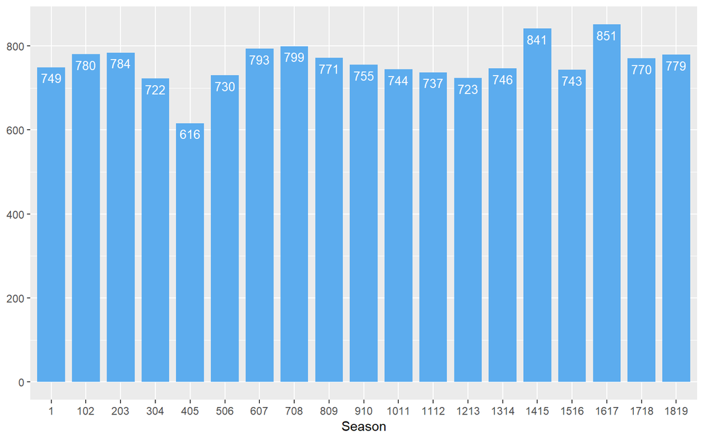

```r
names_months = c("August", "September", "October", "November", "December", "January")

comparing_seasons_cards = df %>%
  mutate(total_yellow_cards = home_yellow_cards + away_yellow_cards,
         year_mon = months(date)) %>%
  select(season, year_mon, total_yellow_cards) %>%
  filter(year_mon %in% names_months) %>%
  group_by(season) %>%
  summarise(total_yellow_cards = sum(total_yellow_cards))


cards_compare_plot = ggplot(data = comparing_seasons_cards,
                            mapping = aes(x = season, y = total_yellow_cards)) +
  geom_bar(stat = "identity", width = 0.8, fill = "steelblue2") +
  geom_text(aes(label = total_yellow_cards),
            vjust = 1.6,
            color = "white",
            size = 3.5) +
  xlab("Season") +
  ylab(NULL)

cards_compare_plot
```

*As we can see, this actual season is on average compared with the other ones, for this specific period of time, so we cannot say that football has suffered from any kind of change just looking at the amount of yellow cards.*

*For seasons 203, 304 and 405, there are some missing registers as seen below. There should be 380 played matches every season. This explains the little gap in the barplot above.*

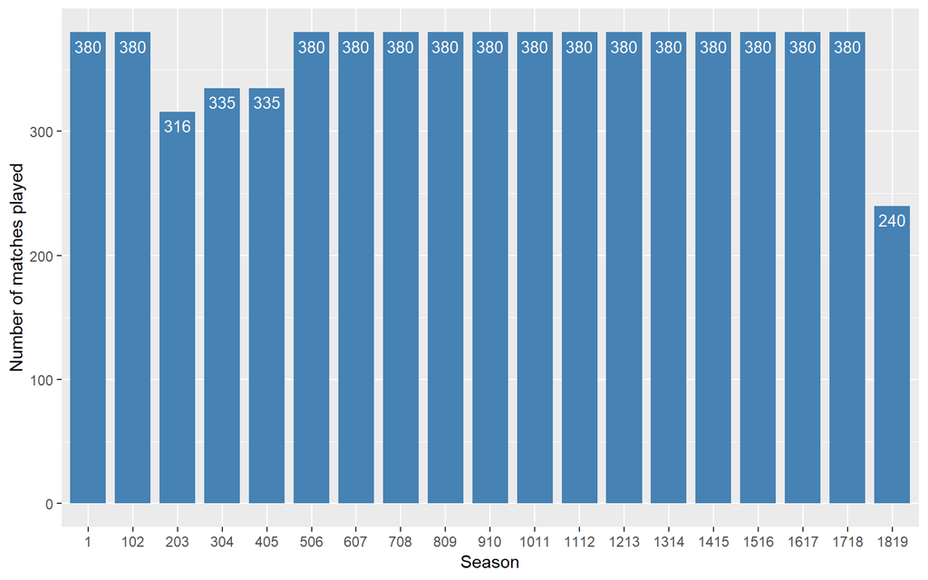

```r
matches_380 = df %>%
  select(season) %>%
  group_by(season) %>%
  summarise(number_of_matches = n())

ggplot(data = matches_380,
       mapping = aes(x = season, y = number_of_matches)) +
  geom_bar(stat = "identity", width = 0.8, fill = "steelblue") +
  geom_text(aes(label = number_of_matches),
            vjust = 1.6,
            color = "white",
            size = 3.5) +
  ylab("Number of matches played") +
  xlab("Season")
```

## **3. Which referees would you describe as the most lenient? Why?**

*The most simple and easy approach is to take a look at the total amount of fouls registered by each referee, in all seasons.*

```r
lenient_referees = df %>%
  transmute(referee, total_fouls = home_fouls + away_fouls) %>%
  group_by(referee) %>%
  summarise(total_fouls = sum(total_fouls),
            n_matches_participated = n()) %>%
  arrange(total_fouls)

kable(head(lenient_referees))
```

| referee | total_fouls | n_matches_participated |
| --- | --- | --- |
| Ian Harris | 22 | 1 |
| M. L. Dean | 23 | 1 |
| St Bennett | 24 | 1 |
| P. Durkin | 25 | 1 |
| I Williamson | 26 | 1 |
| N Yates | 27 | 1 |

*Those are the most lenient referees (using this approach), but they have participated only in 1 match. These takes us to the next idea:*

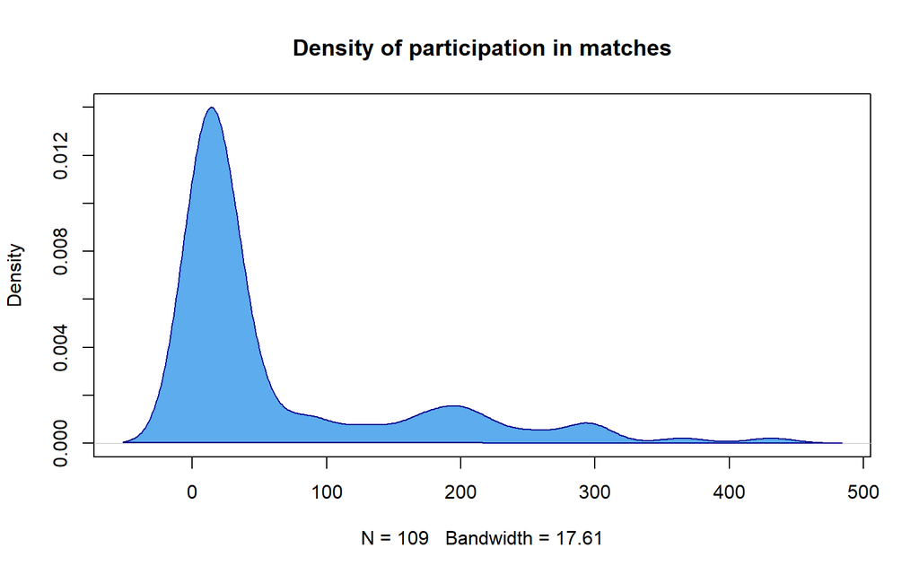

```r
dens = density(lenient_referees$n_matches_participated)
plot(dens, main = "Density of participation in matches")
polygon(dens, col = "steelblue2", border = "darkblue")
```

*Looking at the density graph above, we can see that most of the referees in the database participated in less than 100 matches. Maybe it would be interesting to create bins / cutoffs for a minimum of, for example, 114 matches (3 seasons).*

*Doing so, we would get as the most lenient referees the ones shown below*:

```r
lenient_referees_114 = lenient_referees %>%
  filter(n_matches_participated > 114) %>%
  head()

kable(lenient_referees_114)
```

| referee | total_fouls | n_matches_participated |
| --- | --- | --- |
| N Swarbrick | 2762 | 132 |
| C Pawson | 2793 | 125 |
| P Walton | 3588 | 168 |
| G Poll | 3608 | 130 |
| L Probert | 3720 | 175 |
| R Styles | 3736 | 169 |

## A little further investigation due to curiosity.

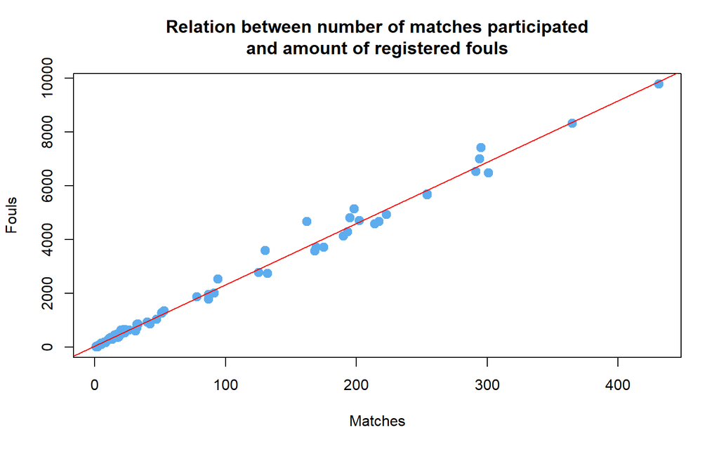

```r
plot(x = lenient_referees$n_matches_participated,
     y = lenient_referees$total_fouls,
     type = "p", cex = 2, pch = 20, col = "steelblue2",
     main = "Relation between number of matches participated\nand amount of registered fouls",
     xlab = "Matches",
     ylab = "Fouls")
abline(lm(lenient_referees$total_fouls ~ lenient_referees$n_matches_participated),
       col = "red")
```

```r
mat = as.matrix(lenient_referees[ ,c("total_fouls", "n_matches_participated")])
kable(cor(mat), caption = "Pearson correlation")
```

Pearson correlation

|  | total_fouls | n_matches_participated |
| --- | --- | --- |
| total_fouls | 1.0000000 | 0.9963647 |
| n_matches_participated | 0.9963647 | 1.0000000 |

*Wanted to see how the number of fouls increased with the number of matches in which a referee has participated. Looks like there is almost a perfect linear correlation between both variables, which a bit weird in my opinion, as I would expect a high correlation between both of them, but 0.99 is too high. This means we could predict the (almost exact) amount of fouls a referee would register depending in how many matches he has participated, and that is just not real. I would say the data has been manipulated somehow, but that is beyond the scope of this report.*

## A different (more complete) approach to find the top 6 lineant referees

**Instead of using the least amount of registered fouls approach, we could use 3 different approaches**:

- Ratio of `yellow+red cards` divided by `amount of fouls`
- Ratio of `yellow+red cards` divided by amount of `matches participated`.

*The first ratio is biased by the amount of matches participated. For example, two referees with the same ratio but the firt one participating in 5 matches, while the other one in 600.*

*The second approach is biased because it does not take in account the amount of fouls per match.*

*The third approach and the one that will be shown below (although the first and second one are calculated too) should be the most complete, as it takes in account the number of matches, number of fouls and number of cards. The formula is* `((cards/fouls)/matches)*1000`. *This ratio resuts to be very small. Multiplying it by 1000 allows for a better understanding of a “ranking parameter”.*

```r
referees = df %>%
  select(season, date, referee, home_fouls, away_fouls, home_yellow_cards, home_red_cards) %>%
  mutate(total_fouls = home_fouls + away_fouls,
         total_cards = home_yellow_cards + home_red_cards)


ratio_cards = referees %>%
  select(referee, total_cards, total_fouls) %>%
  group_by(referee) %>%
  summarise(total_cards = sum(total_cards),

            total_fouls = sum(total_fouls),

            cards_x_foul = formattable(x = (total_cards/total_fouls)*50,
                                       digits = 1,
                                       format = "f"),

            n_matches_participated = n(),

            cards_x_match = formattable(x = total_cards/n_matches_participated,
                                     digits = 1,
                                     format = "f"),

            cards_xfouls_xmatches = formattable(x = ((total_cards/total_fouls)/n_matches_participated)*1000,
                                     digits = 1,
                                     format = "f"))

kable(ratio_cards[order(ratio_cards$cards_xfouls_xmatches, decreasing = F)[1:6], ])
```

| referee | total_cards | total_fouls | cards_x_foul | n_matches_participated | cards_x_match | cards_xfouls_xmatches |
| --- | --- | --- | --- | --- | --- | --- |
| A Madley | 0 | 33 | 0.0 | 2 | 0.0 | 0.0 |
| Ian Harris | 0 | 22 | 0.0 | 1 | 0.0 | 0.0 |
| J.T. Winter | 0 | 32 | 0.0 | 1 | 0.0 | 0.0 |
| P. Durkin | 0 | 25 | 0.0 | 1 | 0.0 | 0.0 |
| P.A. Durkin | 0 | 29 | 0.0 | 1 | 0.0 | 0.0 |
| R Beeby | 0 | 55 | 0.0 | 2 | 0.0 | 0.0 |

*This time the ratio stays 0.0 because the amount of cards shown are 0. It means that, when calculating 0/‘something else’, the ratio stays 0. Let’s just filter the data by at least 5 cards and 114 matches, in order to get something more realistic.*

```r
most_lineant_approach3 = ratio_cards %>%
  select(referee, total_cards, total_fouls, cards_xfouls_xmatches, n_matches_participated) %>%
  filter(total_cards > 5 & n_matches_participated > 114) %>%
  arrange(cards_xfouls_xmatches)

kable(head(most_lineant_approach3))
```

| referee | total_cards | total_fouls | cards_xfouls_xmatches | n_matches_participated |
| --- | --- | --- | --- | --- |
| M Halsey | 185 | 4690 | 0.2 | 217 |
| M Dean | 792 | 9789 | 0.2 | 431 |
| M Atkinson | 574 | 8330 | 0.2 | 365 |
| P Dowd | 449 | 7439 | 0.2 | 295 |
| H Webb | 430 | 7021 | 0.2 | 294 |
| C Foy | 303 | 5711 | 0.2 | 254 |

*This time, we get the most lineant referees as the ones shown in the table.*

David Gibert Bosque

February, 2019